# *Data Structures*: Lists

Cole Ellis

**Homepage** | **Previous**: *Pointers* | **Next**: *Recursion*

## Lists

A *list* is a common ADT for holding ordered items.

Some common list operations include:

- `Append(list, x)`: Insert `x` at end of list
- `Prepend(list, x)`: Insert `x` at beginning of list
- `InsertAfter(list, w, x)`: Insert `x` after `w` in list
- `Remove(list, x)`: Remove `x` from list
- `Search(list, x)`: Find `x` in list, returns index
- `Print(list)`: Prints elements of list in order
- `Sort(list)`: Sorts list in ascending order
- `isEmpty(list)`: Returns true if list is empty, otherwise false
- `GetLength(list)`: Returns number of items in list

## Singly-Linked List

A singly-linked list is a list where each node has data and a pointer to the next node. The last node points to `nullptr`.

- *List Head*: The linked list’s first node
- *List Tail*: The linked list’s last node

A linked list can be interpreted as follows:

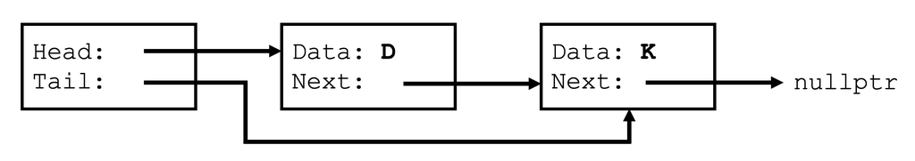

The code to build the list is as follows. Note that this function, along with all the ones below, use a `template`. This idea is discussed in detail later. It’s simply a data type.

```cpp
template <typename T>
class LinkedList {
    private:
        struct Node {
            T item;
            Node* next;
        };
        typedef Node* NodePtr;

        NodePtr head;
};
```

The List *Append* function inserts an item to the end of the list.

```cpp
template <typename T>
void LinkedList<T>::append(const T &data) {
    // create node with data
    NodePtr temp = new Node;
    temp->item = data;
    temp->next = nullptr;

    // if curr is null, insert into head
    if (head == nullptr) {
        head = temp;
        return;
    }

    // walk list to end
    NodePtr curr = head;
    while (curr->next != nullptr) {
        curr = curr->next;
    }

    // link new node into list
    curr->next = temp;
}
```

The List *Prepend* function inserts an item to the start of the list.

```cpp
template <typename T>
void LinkedList<T>::prepend(const T &data) {
    // create node with data
    NodePtr temp = new Node;
    temp->item = data;
    temp->next = head;

    // insert at front
    head = temp;
}
```

The List *InsertAfter* function inserts an item after a given item.

```cpp
template <typename T>
void LinkedList<T>::insertAfter(const T &prev, const T &data) {
    // create node with data
    NodePtr temp = new Node;
    temp->item = data;

    // walk to desired spot in list
    NodePtr curr = head;
    while (curr->next != nullptr) {
        if (curr->item == prev) {
            break;
        }
        curr = curr->next;
    }

    // assign temp next var
    temp->next = curr->next;

    // link node in
    curr->next = temp;
}
```

The List *RemoveAfter* function removes the item after a given item.

```cpp
template <typename T>
void LinkedList<T>::removeAfter(const T &data) {
    // walk to item
    NodePtr prev = head;
    while (prev->item != data) {
        prev = prev->next;
    }
    NodePtr after = prev + 2;
    NodePtr curr = prev + 1;

    // remove and relink
    prev->next = after;
    delete curr;
    curr = nullptr;
}
```

## Doubly-Linked List

A *doubly-linked list* is a list where each node has data, a pointer pointing to the next node, and a pointer to the previous node.

The code to build the list is as follows.

```cpp
class DoubleLinkedList {
    private:
        struct Node {
            T item;

            Node* next;
            Node* prev;
        };
        typedef Node* NodePtr;

        NodePtr head;
};
```

The functionality of all four functions do the exact same thing. Here are all the codes.

```cpp
template <typename T>
void DoubleLinkedList<T>::append(const T &data) {
    // create node with data
    NodePtr temp = new Node;
    temp->item = data;
    temp->next = nullptr;

    // walk list to end
    NodePtr curr = head;
    while (curr->next != nullptr) {
        curr = curr->next;
    }

    // assign prev to curr
    temp->prev = curr;

    // link into list
    curr->next = temp;
}
```

```cpp
template <typename T>
void DoubleLinkedList<T>::prepend(const T &data) {
    // create node with data
    NodePtr temp = new Node;
    temp->item = data;
    temp->prev = nullptr;
    temp->next = head;

    // link into list
    head = temp;
}
```

```cpp
template <typename T>
void DoubleLinkedList<T>::insertAfter(const T &prev, const T &data) {
    // create node with data
    NodePtr temp = new Node;
    temp->item = data;

    // walk list to correct spot
    NodePtr curr = head;
    while (curr->item != prev) {
        curr = curr->next;
    }

    // link temp to list elements
    temp->prev = curr;
    temp->next = curr->next;

    // put temp inside list
    curr->next->prev = temp;
    curr->next = temp;
}
```

```cpp
template <typename T>
void DoubleLinkedList<T>::removeAfter(const T &data) {
    // walk list to spot being removed
    NodePtr curr = head;
    while (curr->item != data) {
        curr = curr->next;
    }
    curr = curr->next;

    // assign previous and next nodes
    NodePtr prevNode = curr->prev;
    NodePtr nextNode = curr->next;

    // delete and re-link
    prevNode->next = nextNode;
    nextNode->prev = prevNode;
    delete curr;
    curr = nullptr;
}
```

## List Traversal

The List Traverse Algorithm visits all nodes once and performs and operation on each node. The code is the same for both Singly-Linked and Doubly-Linked, so only one is shown.

```cpp
template <typename T>
void LinkedList<T>::print() const {
    NodePtr curr = head;

    // if list is empty, do nothing
    if (curr == nullptr) {
        return;
    }

    // otherwise, print the list
    std::cout << "List: ";
    while (curr != nullptr) {
        std::cout << curr->item << " ";
        curr = curr->next;
    }
    std::cout << std::endl;
}
```

Travelling in reverse is doable very easily in doubly-linked lists.

```cpp
void DoubleLinkedList<T>::printReverse() const {
    NodePtr curr = head;

    // if list is empty, do nothing
    if (curr == nullptr) {
        return;
    }

    // otherwise, walk to end
    while (curr != nullptr) {
        curr = curr->next;
    }

    // starting at end, walk back
    std::cout << "List: ";
    while (curr != head) {
        std::cout << curr->item << " ";
        curr = curr->prev;
    }
    std::cout << std::endl;
}
```

Searching is super simple and works the same for singly-linked and doubly-linked lists. The code returns the index it was found, and `-1` if not found.

```cpp
template <typename T>
int LinkedList<T>::search(const T &data) const {
    NodePtr curr = head;
    int index = 0;

    // walk the list and search
    while (curr->next != nullptr) {
        if (curr->item == data) {
            return index;
        }
        curr = curr->next;
        ++index;
    }

    return -1;
}
```

## Circular Linked Lists

```cpp
CircularListTraversal(head) {
    if (head != nullptr) {
        current = head;
        do {
            visit(current);
            current = current->next;
        } while (current != nullptr);
    }
}
```